# Lab 4: Confidence Intervals and OkCupid – Key

By: Dr. Theobold

## Reading in the Data

**1. Insert the path to read in the dataset!**

```r
# Insert the path from the here() function that directs you to the dataset!
profiles <- read_csv(here("Week 7 - Confidence Intervals", "Lab",
                          "data", "profiles_revised.csv"))
```

**Either full credit or a redo.**

Redo if path is not specified with `here()` function!

## Filtering Data

**2. Write the code to filter the `profiles` dataset, so it only contains observations that meet the following criteria:**

- identify as male (“m”)
- identify as “average” or “athletic”

```r
profiles_final <- profiles %>%
  filter(sex == "m",
         body_type %in% c("average", "athletic"))
```

**4**

Write correct `filter()` statements

**3**

Write two separate `filter()` statements

**Redo**

If they miss or have an incorrect filter

## Visualizing Relationships

**3. Create faceted histograms of the distribution of self-reported heights between these two body types.**

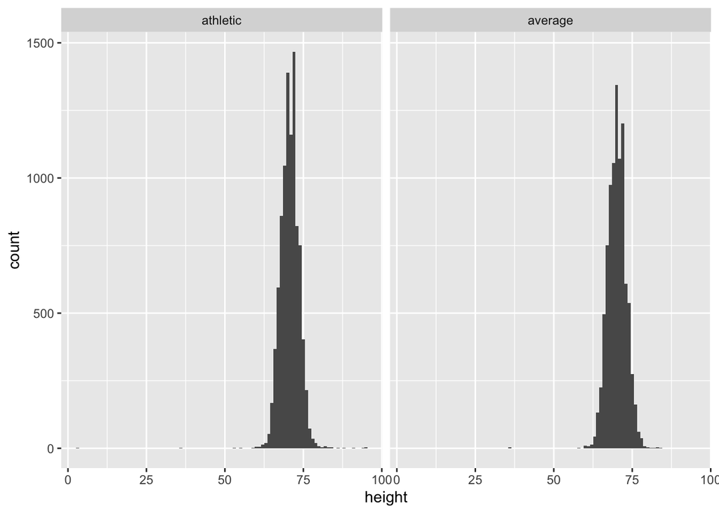

```r
profiles_final %>%
  ggplot(aes(x = height)) +
  geom_histogram(binwidth = 1) +
  facet_wrap(~body_type)
```

**4**

For code given above.

*Consider giving comments on code “readability”.*

**Redo**

If do not use faceting. If do not use histograms.

**4. Do you believe there is a difference in self-reported height between the two body types? Why or why not? Base your argument on the plot above!**

**4**

- Argument states that the distributions appear to have the same center.
- Argument states that the distributions appear to have similar spread.

**Redo**

- Argument talks about either center or spread, but not both.
- Argument suggests the distributions are different.

## Bootstrap Distribution

**5. Generate a bootstrap distribution of differences in means from 1000 bootstrap resamples.**

```r
boot_dist <- profiles_final %>%
  specify(response = height, explanatory = body_type) %>%
  generate(reps = 500, type = "bootstrap") %>%
  calculate(stat = "diff in means")
```

**4**

For code above.

**Redo**

If code is missing any components.  
*Note:* I said it was okay to have 500 reps instead of 1000.

**6. Use the `visualize()` function to create a simple histogram of your 1000 bootstrap statistics.**

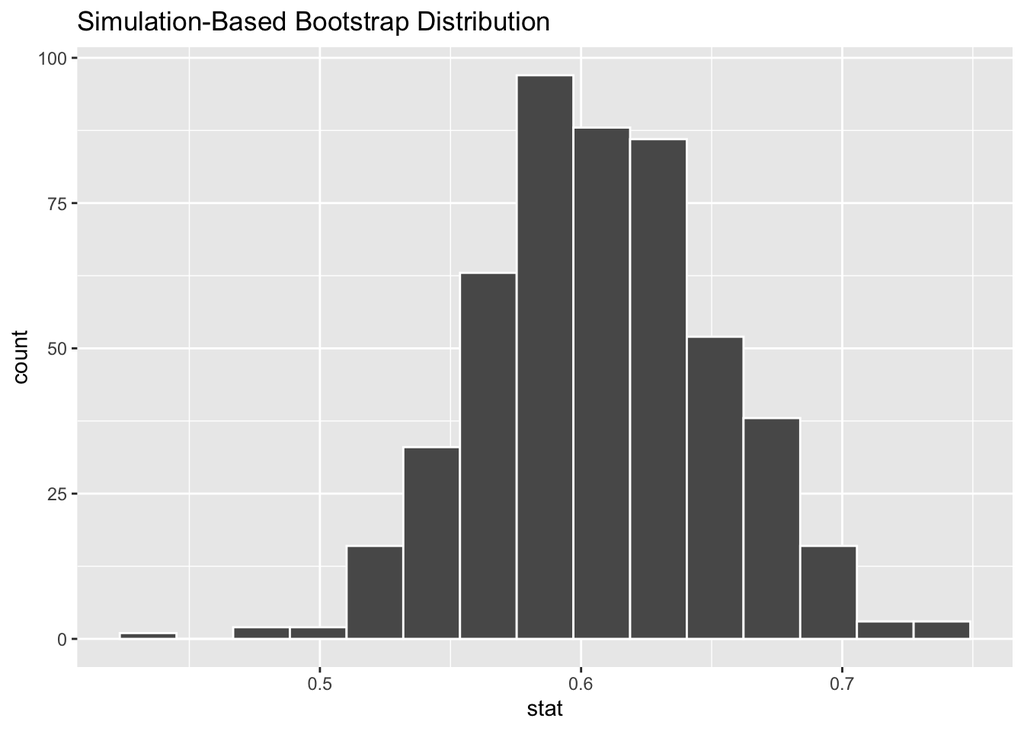

```r
# Code to visualize bootstrap statistics

visualise(boot_dist)
```

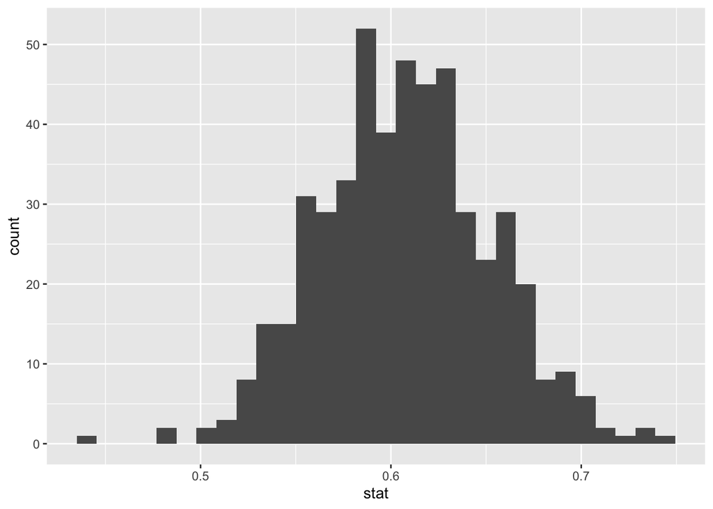

```r
# OR

boot_dist %>%
  ggplot(mapping = aes(x = stat)) +
  geom_histogram()
```

**4**

For using the `visualize()` function *or* using `ggplot()` with `geom_histogram()`

**Redo**

If do not use either of these methods.

## Confidence Interval

**7. Use the `get_confidence_interval()` function to find the 80% confidence interval from your bootstrap distribution. Be sure to use the percentile method!**

```r
get_confidence_interval(boot_dist, level = 0.80, type = "percentile")
```

```
## # A tibble: 1 × 2
##   lower_ci upper_ci
##      <dbl>    <dbl>
## 1    0.552    0.665
```

**4**

For code above.

**3**

If use `level = 0.95`.

**Redo**

If use `type = "se"`

**8. Interpret the confidence interval you obtained in part 7. Make sure to include the context of the data!**

**4**

Has all of the following components:

- States 80% confidence
- States the parameter of interest (difference in mean self-reported height between athletic and average body types)
- States the range of values found above
- States the order of subtraction (athletic - average)

**3**

Has all of the above components *except* for the order of subtraction.

**Redo**

Otherwise

## Bootstrap Assumptions

**9. Based on the information given, how do you feel about the assumption a bootstrap distribution makes about the original sample? What issues do you believe might prevent this assumption being appropriate?)**

*These data are not a random sample of OkCupid users. They are a convenience sample, taken by scraping profile information from OkCupid. Moreover, they are only for users with profile pictures, who had been online in the previous year, and who lived within 25 miles of San Francisco.*

*Because of the nature of how the data were collected, there are a variety of ways the sample could be biased. For example, this sample doesn’t include users without profile pictures or who hadn’t been online in over a year. These biases make it so that I wouldn’t feel comfortable saying that this sample is “representative” of some broader population, even if that population is OkCupid users who lived by San Francisco in the 2010s.*

**4**

The statement should say that the bootstrap assumption about the sample being representative of the population is not valid. The statement should include the following information:

- This was a non-random sample
- The sample is not representative of other OkCupid users

The statement should include *at least* one **reasonable** issue that would bias this sample (e.g., scraping, profile picture, location, last online, etc.)

**Redo**

If missing any of the components